# Econ144 hw1_Sijia

Sijia Hua

4/8/2019

## Econ 144 HW1

### Chapter 2 #2

```r
setwd("/Users/Renaissance/Desktop")
hw11<-read.xls('econ144hw1data.xlsx',sheet = 1) #import data
```

```r
# compute descriptive statistics
 hw11 %>% select(c(-1)) %>% summary()
```

```
##      GRGDP             RETURN
##  Min.   :-2.7075   Min.   :-26.937
##  1st Qu.: 0.3273   1st Qu.: -0.915
##  Median : 0.7679   Median :  2.023
##  Mean   : 0.7958   Mean   :  1.962
##  3rd Qu.: 1.3107   3rd Qu.:  5.753
##  Max.   : 3.9343   Max.   : 20.117
```

```r
paste("The skewness of GRGDP is ", round(skewness(hw11$GRGDP),3),". Hence GRGDP is left-skewness.")
```

```
## [1] "The skewness of GRGDP is  -0.189 . Hence GRGDP is left-skewness."
```

```r
paste("The skewness of Return is ", round(skewness(hw11$RETURN),3),". Hence Return is left-skewness.")
```

```
## [1] "The skewness of Return is  -0.684 . Hence Return is left-skewness."
```

```r
paste("The kurtosis of GRGDP is ",round(kurtosis(hw11$GRGDP),3))
```

```
## [1] "The kurtosis of GRGDP is  4.418"
```

```r
paste("The kurtosis of Return is ",round(kurtosis(hw11$RETURN),3))
```

```
## [1] "The kurtosis of Return is  5.271"
```

```r
paste("The Jarque-Bera Test of GRGDP is ")
```

```
## [1] "The Jarque-Bera Test of GRGDP is "
```

```r
jarque.test(hw11$GRGDP)
```

```
##
##  Jarque-Bera Normality Test
##
## data:  hw11$GRGDP
## JB = 22.265, p-value = 1.463e-05
## alternative hypothesis: greater
```

```r
paste("The Jarque-Bera Test of Return is ")
```

```
## [1] "The Jarque-Bera Test of Return is "
```

```r
jarque.test(hw11$RETURN)
```

```
##
##  Jarque-Bera Normality Test
##
## data:  hw11$RETURN
## JB = 72.627, p-value = 2.22e-16
## alternative hypothesis: greater
```

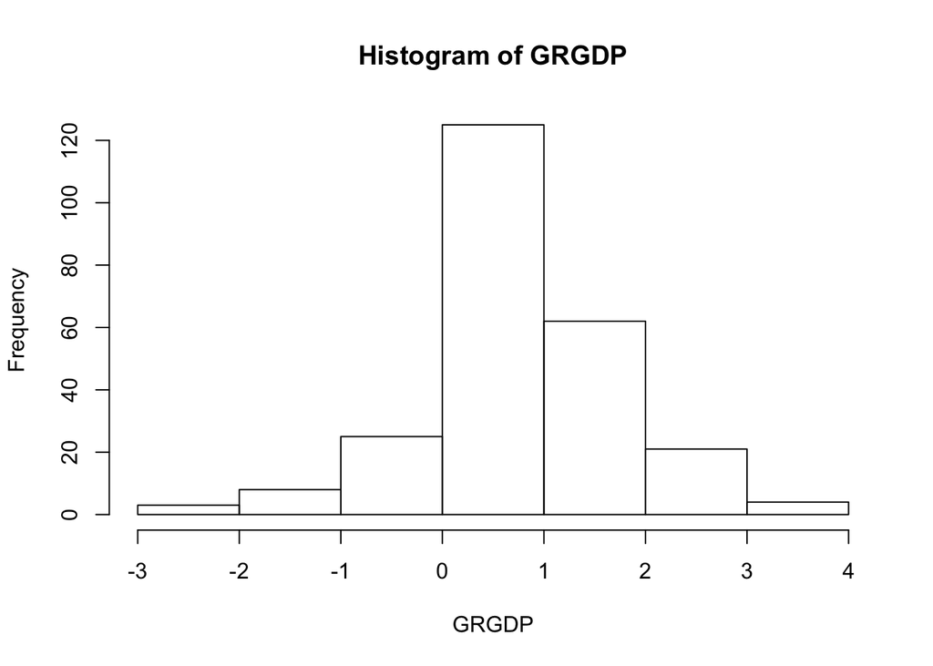

```r
hist(hw11$GRGDP,main="Histogram of GRGDP",xlab="GRGDP")
```

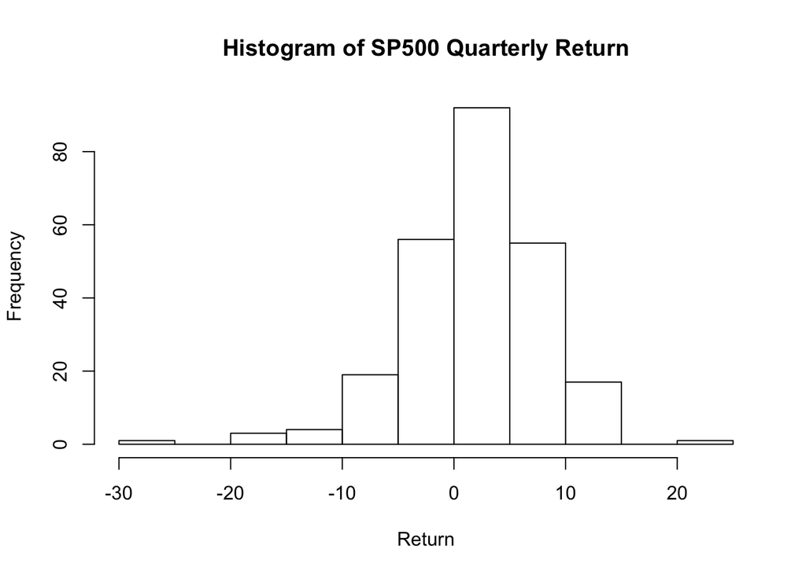

```r
hist(hw11$RETURN, main="Histogram of SP500 Quarterly Return",xlab="Return")
```

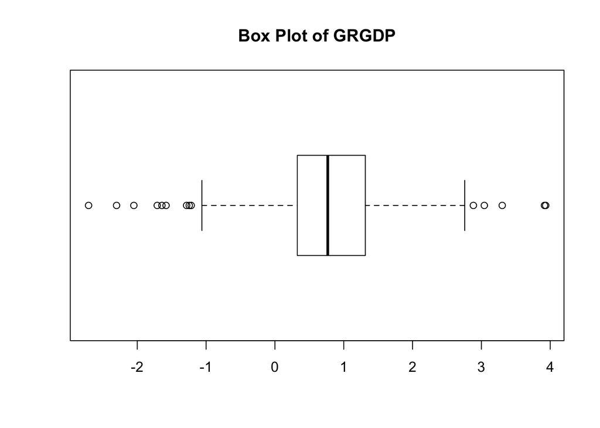

```r
boxplot(hw11$GRGDP,main="Box Plot of GRGDP",horizontal = TRUE)
```

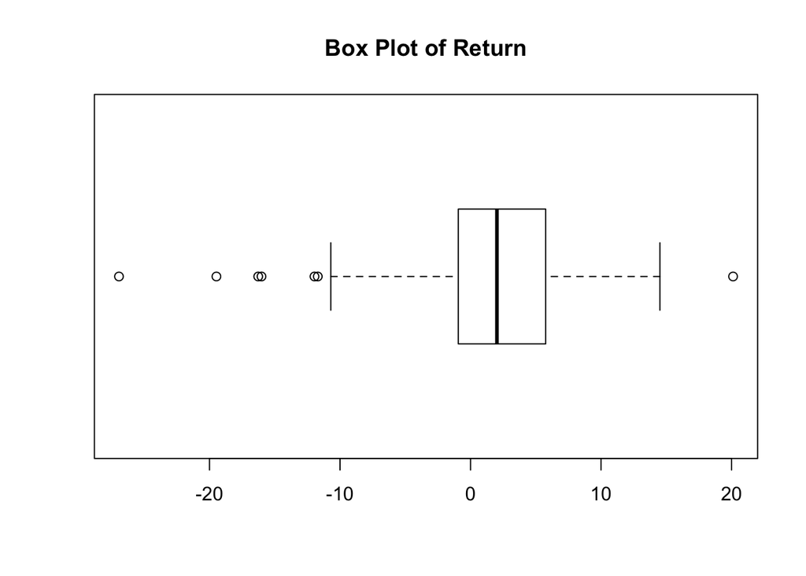

```r
boxplot(hw11$RETURN,main="Box Plot of Return",horizontal = TRUE)
```

```r
# ls <- lm(hw12$GRGDP~hw12$RETURN) #find linear regression between GDP and returns
# summary(ls)
paste("Correlation betwen this two variable is ",round(cor(hw11$RETURN,hw11$GRGDP,method="pearson"),3), ". This indicates that GRGDP has a low correlation with Return.")
```

```
## [1] "Correlation betwen this two variable is  0.27 . This indicates that GRGDP has a low correlation with Return."
```

### Chapter 2 #4

```r
# still use hw11 data
y=ts(hw11$GRGDP,start=1950.25, freq=1)
x=ts(hw11$RETURN,start=1950.25, freq=1)

# (a)
ma=lm(y~x)
summary(ma)
```

```
##
## Call:
## lm(formula = y ~ x)
##
## Residuals:
##     Min      1Q  Median      3Q     Max
## -3.5068 -0.5271 -0.0500  0.5344  3.2189
##
## Coefficients:
##             Estimate Std. Error t value Pr(>|t|)
## (Intercept) 0.710672   0.062819  11.313  < 2e-16 ***
## x           0.043388   0.009856   4.402  1.6e-05 ***
## ---
## Signif. codes:  0 '***' 0.001 '**' 0.01 '*' 0.05 '.' 0.1 ' ' 1
##
## Residual standard error: 0.9412 on 246 degrees of freedom
## Multiple R-squared:  0.07303,    Adjusted R-squared:  0.06926
## F-statistic: 19.38 on 1 and 246 DF,  p-value: 1.597e-05
```

```r
# (b)
mb=dynlm(y~L(x,1))
summary(mb)    #r-square has improved
```

```
##
## Time series regression with "ts" data:
## Start = 1951, End = 2197
##
## Call:
## dynlm(formula = y ~ L(x, 1))
##
## Residuals:
##     Min      1Q  Median      3Q     Max
## -3.0231 -0.5339 -0.0346  0.4720  3.5844
##
## Coefficients:
##             Estimate Std. Error t value Pr(>|t|)
## (Intercept) 0.661818   0.059134  11.192  < 2e-16 ***
## L(x, 1)     0.064728   0.009305   6.956 3.17e-11 ***
## ---
## Signif. codes:  0 '***' 0.001 '**' 0.01 '*' 0.05 '.' 0.1 ' ' 1
##
## Residual standard error: 0.8855 on 245 degrees of freedom
## Multiple R-squared:  0.1649, Adjusted R-squared:  0.1615
## F-statistic: 48.39 on 1 and 245 DF,  p-value: 3.169e-11
```

I choose the significant level = 0.05. As the p-value is 3.17e-11, much less than 0.05, we reject the null hypothesis that β = 0. Hence, there is a (significant) relationship between the variables in the linear regression model of the data set. In this case, stock market is a leading indicator.

### Chapter 2 #5

```r
# (c)
mc=dynlm(y~L(x,1)+L(x,2)+L(x,3)+L(x,4))
summary(mc)
```

```
##
## Time series regression with "ts" data:
## Start = 1954, End = 2197
##
## Call:
## dynlm(formula = y ~ L(x, 1) + L(x, 2) + L(x, 3) + L(x, 4))
##
## Residuals:
##     Min      1Q  Median      3Q     Max
## -2.9786 -0.5113  0.0068  0.4842  3.7592
##
## Coefficients:
##             Estimate Std. Error t value Pr(>|t|)
## (Intercept) 0.571948   0.061504   9.299  < 2e-16 ***
## L(x, 1)     0.056594   0.009735   5.814 1.95e-08 ***
## L(x, 2)     0.018011   0.010471   1.720   0.0867 .
## L(x, 3)     0.015672   0.010493   1.494   0.1366
## L(x, 4)     0.011948   0.009719   1.229   0.2201
## ---
## Signif. codes:  0 '***' 0.001 '**' 0.01 '*' 0.05 '.' 0.1 ' ' 1
##
## Residual standard error: 0.8526 on 239 degrees of freedom
## Multiple R-squared:  0.2066, Adjusted R-squared:  0.1933
## F-statistic: 15.56 on 4 and 239 DF,  p-value: 2.509e-11
```

In summary, The p value of L(x,1) is 1.95e-08, which is smaller than 0.05. We reject H0: _1 =0. The stock market with 1-quarter leading is an indicator. The p value of L(x,2) is 0.0867, which is bigger than 0.05. We can not reject H0. There is no significant difference. Stock market’s 2-quarter leading price may not be an indicator. The p value of L(x,3) and L(x,4) is 0.1366 and 0.2201 respectively, which are bigger than 0.05. We can not reject H0.There is no significant difference.  
P value of the F-statistic is 2.509e-11, which is smaller than 0.05.Hence, we can reject H0, the overall addition of the variables is significantly improving the model.

```r
md=dynlm(y~L(x,1)+L(x,2)+L(x,3)+L(x,4)+L(y,1))
summary(md)
```

```
##
## Time series regression with "ts" data:
## Start = 1954, End = 2197
##
## Call:
## dynlm(formula = y ~ L(x, 1) + L(x, 2) + L(x, 3) + L(x, 4) + L(y,
##     1))
##
## Residuals:
##     Min      1Q  Median      3Q     Max
## -2.8733 -0.4469 -0.0007  0.5037  3.7168
##
## Coefficients:
##             Estimate Std. Error t value Pr(>|t|)
## (Intercept) 0.444490   0.069652   6.382 9.07e-10 ***
## L(x, 1)     0.050535   0.009646   5.239 3.56e-07 ***
## L(x, 2)     0.007459   0.010629   0.702 0.483503
## L(x, 3)     0.011149   0.010316   1.081 0.280918
## L(x, 4)     0.007133   0.009577   0.745 0.457103
## L(y, 1)     0.230396   0.063898   3.606 0.000379 ***
## ---
## Signif. codes:  0 '***' 0.001 '**' 0.01 '*' 0.05 '.' 0.1 ' ' 1
##
## Residual standard error: 0.832 on 238 degrees of freedom
## Multiple R-squared:  0.2477, Adjusted R-squared:  0.2319
## F-statistic: 15.67 on 5 and 238 DF,  p-value: 2.483e-13
```

### Chapter 2 #7

```r
hw12<-read.xls('econ144hw1data.xlsx',sheet = 2) # read data

# calculate growth rate
grate_unem <- function(x)(x/lag(x)-1)*100
hw12$growth_unem <-round(grate_unem(hw12$UNEM),3)
grate_pov <- function(x)(x/lag(x)-1)*100
hw12$growth_pov <- round(grate_pov(hw12$POV),3)

# delete blank column
hw12<-hw12%>% select(c(-4))

# drop first row (NA)
newhw12 <- hw12 %>% drop_na()
```

### descriptive statistics of two growth rates

```r
# descriptive statistic
summary(hw12)
```

```
##       year           POV             UNEM        growth_unem
##  Min.   :1959   Min.   :22973   Min.   : 2797   Min.   :-20.245
##  1st Qu.:1972   1st Qu.:28325   1st Qu.: 4834   1st Qu.: -7.125
##  Median :1984   Median :33642   Median : 6979   Median : -2.376
##  Mean   :1984   Mean   :32982   Mean   : 6795   Mean   :  4.004
##  3rd Qu.:1997   3rd Qu.:36634   3rd Qu.: 8253   3rd Qu.:  9.735
##  Max.   :2010   Max.   :46180   Max.   :14815   Max.   : 59.770
##                                                 NA's   :1
##    growth_pov
##  Min.   :-14.0880
##  1st Qu.: -3.0790
##  Median : -0.5600
##  Mean   :  0.4489
##  3rd Qu.:  4.6265
##  Max.   : 12.2740
##  NA's   :1
```

```r
paste("The skewness of growth rate of unemployed persons is ", round(skewness(newhw12$growth_unem),3),". Hence the growth rate of unemployed person is right-skewness.")
```

```
## [1] "The skewness of growth rate of unemployed persons is  1.425 . Hence the growth rate of unemployed person is right-skewness."
```

```r
paste("The skewness of growth rate of number of people in poverty is ", round(skewness(newhw12$growth_pov),3),". Hence Return is right-skewness.")
```

```
## [1] "The skewness of growth rate of number of people in poverty is  0.027 . Hence Return is right-skewness."
```

```r
paste("The kurtosis of growth rate of unemployed person is ",round(kurtosis(newhw12$growth_unem),3))
```

```
## [1] "The kurtosis of growth rate of unemployed person is  4.74"
```

```r
paste("The kurtosis of growth rate of number of people in poverty is ",round(kurtosis(newhw12$growth_pov),3))
```

```
## [1] "The kurtosis of growth rate of number of people in poverty is  2.885"
```

```r
paste("The Jarque-Bera Test of growth rate of unemployed person is ")
```

```
## [1] "The Jarque-Bera Test of growth rate of unemployed person is "
```

```r
jarque.test(newhw12$growth_unem)
```

```
##
##  Jarque-Bera Normality Test
##
## data:  newhw12$growth_unem
## JB = 23.703, p-value = 7.127e-06
## alternative hypothesis: greater
```

```r
paste("The Jarque-Bera Test of growth rate of number of people is ")
```

```
## [1] "The Jarque-Bera Test of growth rate of number of people is "
```

```r
jarque.test(newhw12$growth_pov)
```

```
##
##  Jarque-Bera Normality Test
##
## data:  newhw12$growth_pov
## JB = 0.034273, p-value = 0.983
## alternative hypothesis: greater
```

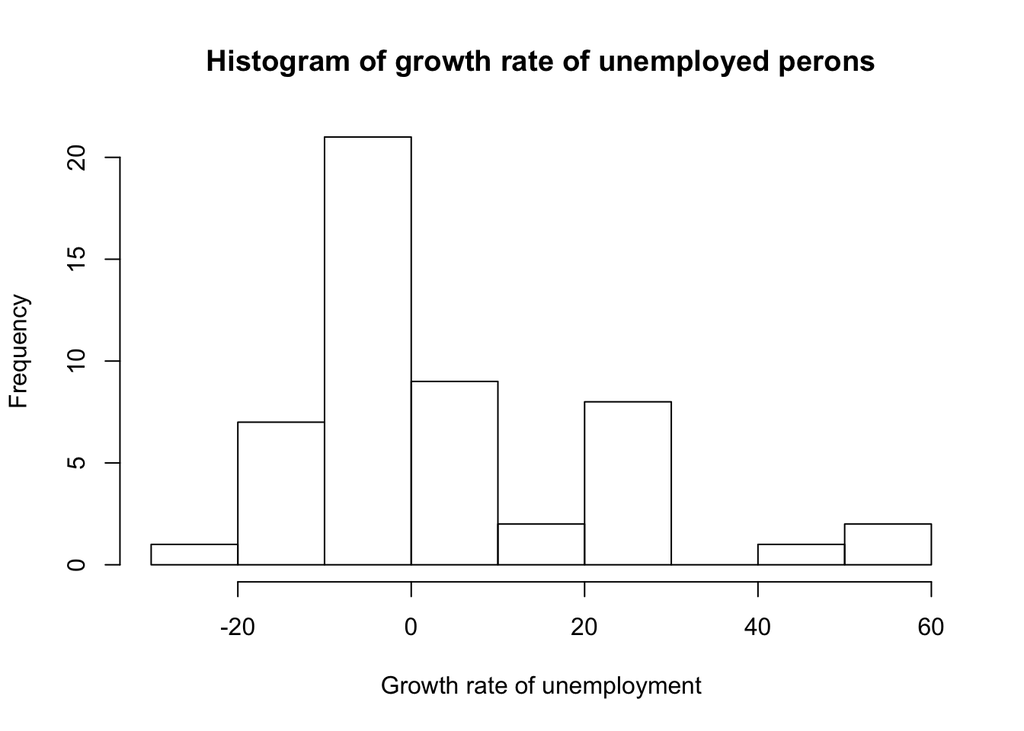

```r
hist(hw12$growth_unem,main="Histogram of growth rate of unemployed perons",xlab="Growth rate of unemployment")
```

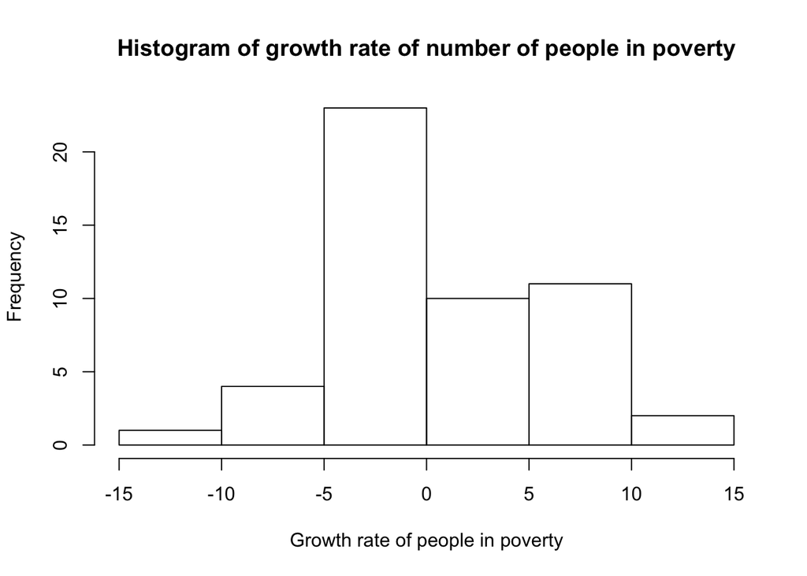

```r
hist(hw12$growth_pov, main="Histogram of growth rate of number of people in poverty",xlab="Growth rate of people in poverty")
```

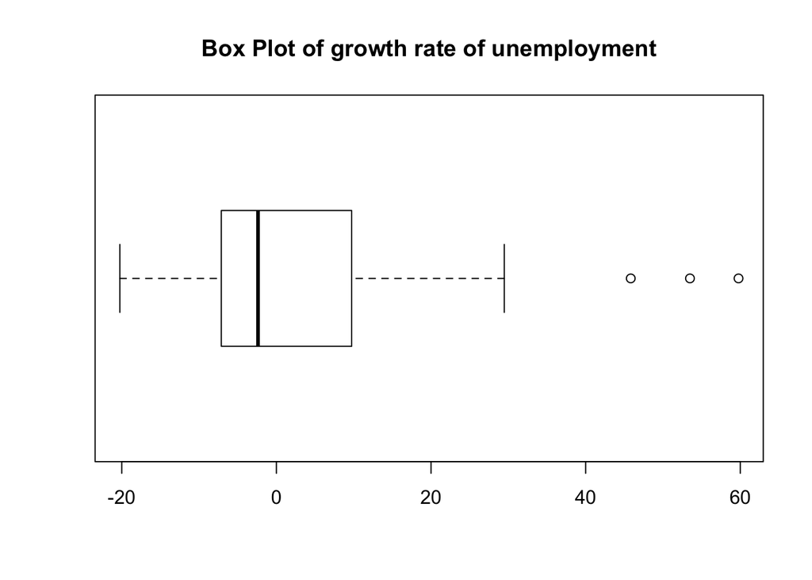

```r
boxplot(hw12$growth_unem,main="Box Plot of growth rate of unemployment",horizontal = TRUE)
```

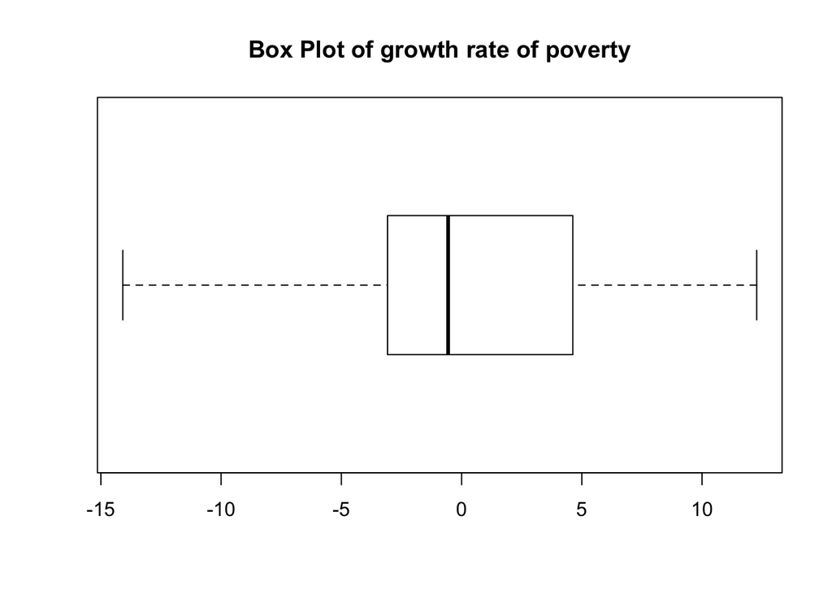

```r
boxplot(hw12$growth_pov,main="Box Plot of growth rate of poverty",horizontal = TRUE)
```

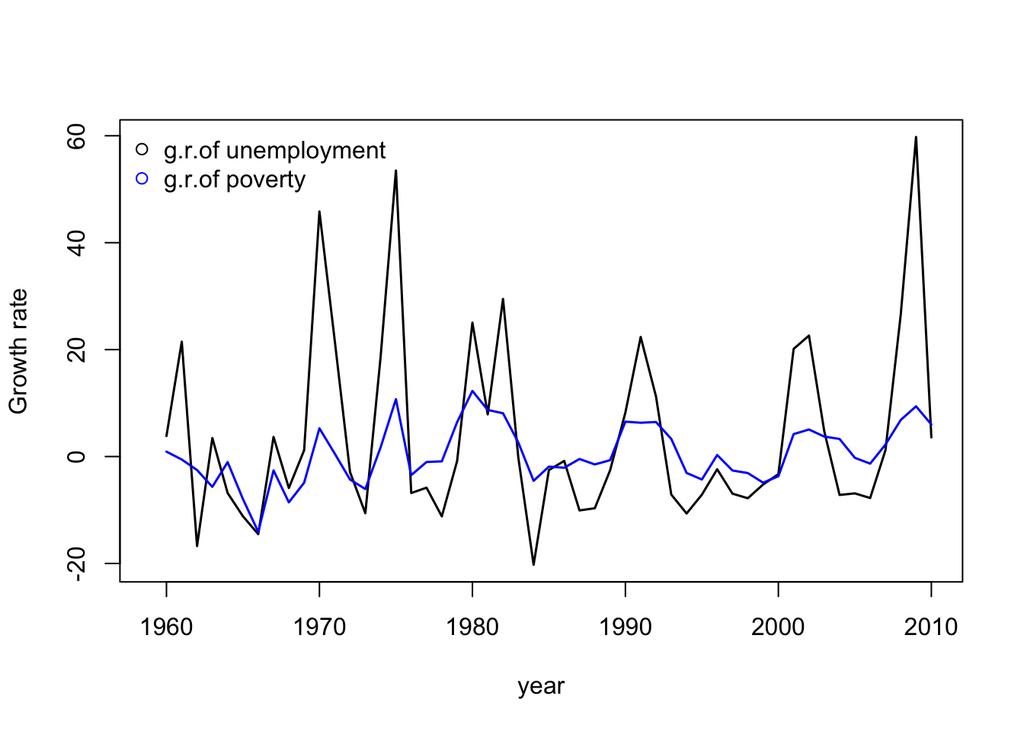

```r
plot(hw12$year,hw12$growth_unem,type="l",lwd = 1.5,xlab = "year",ylab="Growth rate")
lines(hw12$year,hw12$growth_pov,type="l",lwd=1.5, col="blue")
legend("topleft", legend = c("g.r.of unemployment", "g.r.of poverty"), col = c("black","blue"), pch = c(1,1), bty = "n", pt.cex = 1, cex = 1, text.col = "black", horiz = F)
```

```r
paste("Correlation betwen this two variable is ",round(cor(hw11$RETURN,hw11$GRGDP,method="pearson"),3), ". This indicates that GRGDP has a low correlation with Return.")
```

```
## [1] "Correlation betwen this two variable is  0.27 . This indicates that GRGDP has a low correlation with Return."
```

### Chapter 2 #8

```r
hw13<-read.xls('econ144hw1data.xlsx',sheet = 3) # read data
y=ts(hw13$G_POV,start=1960, freq=1)
x=ts(hw13$G_UNEM,start=1960, freq=1)
```

```r
# (a)
modela=lm(y~x)
summary(modela)
```

```
##
## Call:
## lm(formula = y ~ x)
##
## Residuals:
##      Min       1Q   Median       3Q      Max
## -10.4671  -2.7537   0.3376   2.0197   7.4094
##
## Coefficients:
##             Estimate Std. Error t value Pr(>|t|)
## (Intercept)  -0.4307     0.5498  -0.783    0.437
## x             0.2197     0.0311   7.063  5.3e-09 ***
## ---
## Signif. codes:  0 '***' 0.001 '**' 0.01 '*' 0.05 '.' 0.1 ' ' 1
##
## Residual standard error: 3.825 on 49 degrees of freedom
## Multiple R-squared:  0.5045, Adjusted R-squared:  0.4944
## F-statistic: 49.89 on 1 and 49 DF,  p-value: 5.296e-09
```

For model a, multiple R-squared is 0.5045, adjusted R-squared is 0.4944.

```r
# I choose model b,c,d in excercise #3

# (b)
modelb=dynlm(y~L(x,1))
summary(modelb)
```

```
##
## Time series regression with "ts" data:
## Start = 1961, End = 2010
##
## Call:
## dynlm(formula = y ~ L(x, 1))
##
## Residuals:
##      Min       1Q   Median       3Q      Max
## -12.8549  -3.1164  -0.3667   3.0453  12.3684
##
## Coefficients:
##              Estimate Std. Error t value Pr(>|t|)
## (Intercept) -0.002186   0.744465  -0.003   0.9977
## L(x, 1)      0.110109   0.041716   2.640   0.0112 *
## ---
## Signif. codes:  0 '***' 0.001 '**' 0.01 '*' 0.05 '.' 0.1 ' ' 1
##
## Residual standard error: 5.129 on 48 degrees of freedom
## Multiple R-squared:  0.1267, Adjusted R-squared:  0.1086
## F-statistic: 6.967 on 1 and 48 DF,  p-value: 0.01116
```

For model b, multiple R-squared is 0.1267, adjusted r-squared is 0.1086.

```r
# (c)
modelc=dynlm(y~L(x,1)+L(x,2)+L(x,3)+L(x,4))
summary(modelc)
```

```
##
## Time series regression with "ts" data:
## Start = 1964, End = 2010
##
## Call:
## dynlm(formula = y ~ L(x, 1) + L(x, 2) + L(x, 3) + L(x, 4))
##
## Residuals:
##      Min       1Q   Median       3Q      Max
## -12.8470  -3.6448  -0.1239   3.9760  11.5391
##
## Coefficients:
##             Estimate Std. Error t value Pr(>|t|)
## (Intercept)  0.26221    0.81984   0.320   0.7507
## L(x, 1)      0.12840    0.04971   2.583   0.0134 *
## L(x, 2)     -0.05268    0.05695  -0.925   0.3602
## L(x, 3)     -0.02281    0.05563  -0.410   0.6838
## L(x, 4)      0.02086    0.05375   0.388   0.6998
## ---
## Signif. codes:  0 '***' 0.001 '**' 0.01 '*' 0.05 '.' 0.1 ' ' 1
##
## Residual standard error: 5.287 on 42 degrees of freedom
## Multiple R-squared:  0.1596, Adjusted R-squared:  0.07957
## F-statistic: 1.994 on 4 and 42 DF,  p-value: 0.1129
```

For model c, multiple R-squared is 0.1596, adjusted R-squared is 0.07957.

```r
# (d)
modeld=dynlm(y~L(x,1)+L(x,2)+L(x,3)+L(x,4)+L(y,1))
summary(modeld)
```

```
##
## Time series regression with "ts" data:
## Start = 1964, End = 2010
##
## Call:
## dynlm(formula = y ~ L(x, 1) + L(x, 2) + L(x, 3) + L(x, 4) + L(y,
##     1))
##
## Residuals:
##     Min      1Q  Median      3Q     Max
## -9.9066 -2.6588  0.2105  3.1978  8.1328
##
## Coefficients:
##             Estimate Std. Error t value Pr(>|t|)
## (Intercept)  0.67751    0.72750   0.931 0.357157
## L(x, 1)     -0.01948    0.05918  -0.329 0.743647
## L(x, 2)     -0.07897    0.05043  -1.566 0.125031
## L(x, 3)     -0.02047    0.04877  -0.420 0.676876
## L(x, 4)      0.00998    0.04722   0.211 0.833648
## L(y, 1)      0.67568    0.18293   3.694 0.000646 ***
## ---
## Signif. codes:  0 '***' 0.001 '**' 0.01 '*' 0.05 '.' 0.1 ' ' 1
##
## Residual standard error: 4.635 on 41 degrees of freedom
## Multiple R-squared:  0.3694, Adjusted R-squared:  0.2925
## F-statistic: 4.804 on 5 and 41 DF,  p-value: 0.001509
```

For model d, multiple R-squared is 0.3694, adjusted R-squared is 0.2925.

By comparing adjusted R-squared, I prefer model a.  
Compare AIC and BIC:

```r
AIC(modela,modelb,modelc,modeld)
```

```
##        df      AIC
## modela  3 285.5185
## modelb  3 309.3521
## modelc  6 296.6272
## modeld  7 285.1260
```

```r
BIC(modela,modelb,modelc,modeld)
```

```
##        df      BIC
## modela  3 291.3139
## modelb  3 315.0881
## modelc  6 307.7281
## modeld  7 298.0771
```